# Regression and Variable Selection

# 1 Objective

The objective of this case is to get you started with regression model building, variable selection, and model evaluation in R.

We use Boston Housing Data as an illustrative example in this lab. We learn basic linear regression and analysis with R. Code in this file is not the only correct way to do things, however it is important for you to understand what each statement does. You will have to modify the code accordingly for your homework.

# 2 Boston Housing Data

Boston housing data is a built-in dataset in `MASS` package, so you do not need to download externally. Package `MASS` comes with R when you installed R, so no need to use `install.packages(MASS)` to download and install, but you do need to load this package.

## 2.1 Load Data

```r
library(MASS)
data(Boston); #this data is in MASS package
colnames(Boston)
```

```
##  [1] "crim"    "zn"      "indus"   "chas"    "nox"     "rm"      "age"
##  [8] "dis"     "rad"     "tax"     "ptratio" "black"   "lstat"   "medv"
```

You can find details of the dataset from help document.

```r
?Boston
```

We skip the Exploratory Data Analysis (EDA) in this notes, but you should not omit it in your HW and Cases. EDA is very important and always the first analysis to do before any modeling.

## 2.2 Preparation

### 2.2.1 Splitting data to training and testing samples

Next we sample 90% of the original data and use it as the training set. The remaining 10% is used as test set. The regression model will be built on the training set and future performance of your model will be evaluated with the test set.

```r
sample_index <- sample(nrow(Boston),nrow(Boston)*0.90)
Boston_train <- Boston[sample_index,]
Boston_test <- Boston[-sample_index,]
```

### 2.2.2 (Optional) Standardization

If we want our results to be invariant to the units and the parameter estimates $\beta_i$ to be comparible, we can standardize the variables. Essentially we are replacing the original values with their z-score.

1st Way: create new variables manually.

```r
Boston$sd.crim <- (Boston$crim-mean(Boston$crim))/sd(Boston$crim);
```

This does the same thing.

```r
Boston$sd.crim <- scale(Boston$crim);
```

2nd way: If you have a lot of variables to standardize then the above is not very pleasing to do. You can use a loop like this. It standardizes every varables other than the last one which is $y$.

```r
for (i in 1:(ncol(Boston_train)-1)){
  Boston_train[,i] <- scale(Boston_train[,i])
}
```

The technique is not as important in linear regression because it will only affect the interpretation but not the model estimation and inference.

go to top

# 3 Variable Selection

## 3.1 Compare Model Fit Manually

```r
model_1 <- lm(medv~., data = Boston_train)
model_2 <- lm(medv~crim+zn, data = Boston_train)
summary(model_1)
summary(model_2)
AIC(model_1); BIC(model_1)
AIC(model_2); BIC(model_2)
```

## 3.2 Best Subset Regression

The ‘leaps’ package provides procedures for best subset regression.

```r
install.packages('leaps')
```

```r
library(leaps)
```

Which subset of variables should you include in order to minimize BIC?

```r
#regsubsets only takes data frame as input
subset_result <- regsubsets(medv~.,data=Boston_train, nbest=2, nvmax = 14)
summary(subset_result)
```

```
## Subset selection object
## Call: regsubsets.formula(medv ~ ., data = Boston_train, nbest = 2,
##     nvmax = 14)
## 13 Variables  (and intercept)
##         Forced in Forced out
## crim        FALSE      FALSE
## zn          FALSE      FALSE
## indus       FALSE      FALSE
## chas        FALSE      FALSE
## nox         FALSE      FALSE
## rm          FALSE      FALSE
## age         FALSE      FALSE
## dis         FALSE      FALSE
## rad         FALSE      FALSE
## tax         FALSE      FALSE
## ptratio     FALSE      FALSE
## black       FALSE      FALSE
## lstat       FALSE      FALSE
## 2 subsets of each size up to 13
## Selection Algorithm: exhaustive
##           crim zn  indus chas nox rm  age dis rad tax ptratio black lstat
## 1  ( 1 )  " "  " " " "   " "  " " " " " " " " " " " " " "     " "   "*"
## 1  ( 2 )  " "  " " " "   " "  " " "*" " " " " " " " " " "     " "   " "
## 2  ( 1 )  " "  " " " "   " "  " " "*" " " " " " " " " " "     " "   "*"
## 2  ( 2 )  " "  " " " "   " "  " " " " " " " " " " " " "*"     " "   "*"
## 3  ( 1 )  " "  " " " "   " "  " " "*" " " " " " " " " "*"     " "   "*"
## 3  ( 2 )  " "  " " " "   "*"  " " "*" " " " " " " " " " "     " "   "*"
## 4  ( 1 )  " "  " " " "   " "  " " "*" " " "*" " " " " "*"     " "   "*"
## 4  ( 2 )  " "  " " " "   "*"  " " "*" " " " " " " " " "*"     " "   "*"
## 5  ( 1 )  " "  " " " "   " "  "*" "*" " " "*" " " " " "*"     " "   "*"
## 5  ( 2 )  " "  " " " "   " "  " " "*" " " "*" " " " " "*"     "*"   "*"
## 6  ( 1 )  " "  " " " "   "*"  "*" "*" " " "*" " " " " "*"     " "   "*"
## 6  ( 2 )  " "  " " " "   " "  "*" "*" " " "*" " " " " "*"     "*"   "*"
## 7  ( 1 )  " "  " " " "   "*"  "*" "*" " " "*" " " " " "*"     "*"   "*"
## 7  ( 2 )  " "  "*" " "   "*"  "*" "*" " " "*" " " " " "*"     " "   "*"
## 8  ( 1 )  " "  "*" " "   "*"  "*" "*" " " "*" " " " " "*"     "*"   "*"
## 8  ( 2 )  " "  " " " "   "*"  "*" "*" " " "*" "*" " " "*"     "*"   "*"
## 9  ( 1 )  "*"  " " " "   "*"  "*" "*" " " "*" "*" " " "*"     "*"   "*"
## 9  ( 2 )  " "  " " " "   "*"  "*" "*" " " "*" "*" "*" "*"     "*"   "*"
## 10  ( 1 ) "*"  "*" " "   " "  "*" "*" " " "*" "*" "*" "*"     "*"   "*"
## 10  ( 2 ) " "  "*" " "   "*"  "*" "*" " " "*" "*" "*" "*"     "*"   "*"
## 11  ( 1 ) "*"  "*" " "   "*"  "*" "*" " " "*" "*" "*" "*"     "*"   "*"
## 11  ( 2 ) "*"  "*" "*"   " "  "*" "*" " " "*" "*" "*" "*"     "*"   "*"
## 12  ( 1 ) "*"  "*" "*"   "*"  "*" "*" " " "*" "*" "*" "*"     "*"   "*"
## 12  ( 2 ) "*"  "*" " "   "*"  "*" "*" "*" "*" "*" "*" "*"     "*"   "*"
## 13  ( 1 ) "*"  "*" "*"   "*"  "*" "*" "*" "*" "*" "*" "*"     "*"   "*"
```

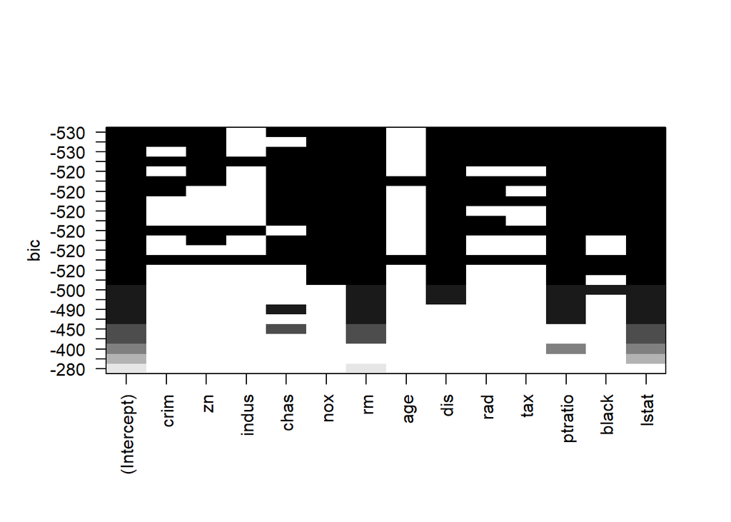

```r
plot(subset_result, scale="bic")
```

Each row represents a model. Black indicates that a variable is included in the model, while white indicates that it is not. The argument `scale = ""` can be “Cp”, “adjr2”, “r2” or “bic”.

What is the problem with best subset regression? If there are n independent variables, the number of possible nonempty subsets is 2^n - 1. If you try a best subset regression with more than 50 variables, you might need to wait for your entire life to get the result.

## 3.3 Forward/Backward/Stepwise Regression Using AIC

To perform the Forward/Backward/Stepwise Regression in R, we need to define the starting points:

```r
nullmodel=lm(medv~1, data=Boston_train)
fullmodel=lm(medv~., data=Boston_train)
```

nullmodel is the model with no varaible in it, while fullmodel is the model with every variable in it.

### 3.3.1 Backward Elimination

```r
model_step_b <- step(fullmodel,direction='backward')
```

```
## Start:  AIC=1454.4
## medv ~ crim + zn + indus + chas + nox + rm + age + dis + rad +
##     tax + ptratio + black + lstat
##
##           Df Sum of Sq   RSS    AIC
## - age      1      2.25 10462 1452.5
## - indus    1     21.14 10480 1453.3
## <none>                 10459 1454.4
## - chas     1    201.89 10661 1461.1
## - crim     1    223.37 10683 1462.0
## - black    1    236.31 10696 1462.6
## - tax      1    270.13 10729 1464.0
## - zn       1    273.19 10732 1464.1
## - rad      1    483.98 10943 1473.0
## - nox      1    514.28 10974 1474.2
## - dis      1   1136.16 11595 1499.3
## - ptratio  1   1161.49 11621 1500.3
## - rm       1   1675.87 12135 1520.0
## - lstat    1   2411.50 12871 1546.8
##
## Step:  AIC=1452.5
## medv ~ crim + zn + indus + chas + nox + rm + dis + rad + tax +
##     ptratio + black + lstat
##
##           Df Sum of Sq   RSS    AIC
## - indus    1     21.06 10483 1451.4
## <none>                 10462 1452.5
## - chas     1    204.22 10666 1459.3
## - crim     1    223.09 10685 1460.1
## - black    1    240.24 10702 1460.8
## - tax      1    268.61 10730 1462.0
## - zn       1    271.13 10733 1462.1
## - rad      1    481.88 10943 1471.0
## - nox      1    534.81 10996 1473.2
## - ptratio  1   1162.24 11624 1498.4
## - dis      1   1271.87 11733 1502.7
## - rm       1   1771.99 12234 1521.7
## - lstat    1   2678.82 13140 1554.2
##
## Step:  AIC=1451.41
## medv ~ crim + zn + chas + nox + rm + dis + rad + tax + ptratio +
##     black + lstat
##
##           Df Sum of Sq   RSS    AIC
## <none>                 10483 1451.4
## - chas     1    220.71 10703 1458.9
## - crim     1    228.06 10711 1459.2
## - black    1    237.30 10720 1459.6
## - tax      1    253.37 10736 1460.3
## - zn       1    256.53 10739 1460.4
## - rad      1    462.02 10945 1469.0
## - nox      1    517.44 11000 1471.3
## - ptratio  1   1141.54 11624 1496.5
## - dis      1   1408.47 11891 1506.8
## - rm       1   1751.88 12234 1519.7
## - lstat    1   2657.86 13140 1552.2
```

### 3.3.2 Forward Selection

```r
model_step_f <- step(nullmodel, scope=list(lower=nullmodel, upper=fullmodel), direction='forward')
```

```
## Start:  AIC=2032.35
## medv ~ 1
##
##           Df Sum of Sq   RSS    AIC
## + lstat    1   21147.7 18295 1684.8
## + rm       1   18645.2 20797 1743.1
## + ptratio  1    9906.6 29536 1902.8
## + indus    1    8439.3 31003 1924.8
## + tax      1    7954.2 31488 1931.9
## + nox      1    7177.6 32265 1943.0
## + age      1    5783.9 33659 1962.2
## + crim     1    5657.5 33785 1963.9
## + rad      1    5430.0 34013 1967.0
## + zn       1    5286.9 34156 1968.9
## + black    1    4453.1 34990 1979.8
## + dis      1    2512.1 36931 2004.4
## + chas     1    1303.6 38139 2019.1
## <none>                 39443 2032.3
##
## Step:  AIC=1684.81
## medv ~ lstat
##
##           Df Sum of Sq   RSS    AIC
## + rm       1    3745.2 14550 1582.6
## + ptratio  1    2442.0 15853 1621.6
## + chas     1     745.2 17550 1667.9
## + dis      1     711.8 17583 1668.8
## + age      1     265.5 18030 1680.2
## + tax      1     222.8 18072 1681.2
## + black    1     174.5 18121 1682.5
## + zn       1     157.1 18138 1682.9
## + crim     1     118.5 18176 1683.8
## <none>                 18295 1684.8
## + indus    1      43.6 18251 1685.7
## + rad      1      17.4 18278 1686.4
## + nox      1       3.5 18291 1686.7
##
## Step:  AIC=1582.59
## medv ~ lstat + rm
##
```

[output cut: 109 more lines]

```
##
##         Df Sum of Sq   RSS    AIC
## + tax    1   253.369 10483 1451.4
## <none>               10736 1460.3
## + indus  1     5.823 10730 1462.0
## + age    1     0.686 10735 1462.2
##
## Step:  AIC=1451.41
## medv ~ lstat + rm + ptratio + dis + nox + chas + black + zn +
##     crim + rad + tax
##
##         Df Sum of Sq   RSS    AIC
## <none>               10483 1451.4
## + indus  1   21.0638 10462 1452.5
## + age    1    2.1665 10480 1453.3
```

### 3.3.3 Stepwise Selection (Output Omitted)

```r
model_step_s <- step(nullmodel, scope=list(lower=nullmodel, upper=fullmodel), direction='both')
```

One caution when comparing fit statistics using AIC, the definition varies by program/procedure.

```r
model_1 <- lm(medv~crim+zn+chas+nox+rm+dis+rad+tax+ptratio+black+lstat, data=Boston_train)
extractAIC(model_1)
```

```
## [1]   12.000 1451.414
```

```r
AIC(model_1)
```

```
## [1] 2744.648
```

> Exercise
> 1. Comparing in-sample and out-of-sample performance between these reduced models.
> 2. Conduct 10-fold cross validation on the full sample and compare the CV scores.
- For pros and cons of variable/model selection using the common fit statistics: (adjusted) $R^2$, MSE, AIC, BIC, etc. refer to Ch9 in “Applied Linear Regression Models” by Kutner et al.
- For other variable selection methods refer to section 3.4 - 3.8 of [“Elements of Statistical Learning” (Free Online)](http://www-stat.stanford.edu/~tibs/ElemStatLearn/).

go to top

## 3.4 Lasso and Elastic net

Two of the state-of-the-art automatic variable selection techniques of predictive modeling , Lasso [1] and Elastic net [2], are provided in the *glmnet* package. These method are in general better than the stepwise regressions, especially when dealing with large amount of predictor variables.

For a more theoretical review of these techniques refer to section 3.4 - 3.8 of [“Elements of Statistical Learning” (Free Online)](http://www-stat.stanford.edu/~tibs/ElemStatLearn/). For more details of the glmnet package you can watch [Professor Trevor Hastie’s presentation](http://www.youtube.com/watch?v=BU2gjoLPfDc).

In short, Lasso and Elastic net are solving this optimization problem [2] :

$$\begin{array}
{rl}
\hat{\beta}= & \underset{\beta}{\text{argmin}}|y-X\beta|^2_2 \\
\text{subject to} & (1-\alpha)|\beta|_1+\alpha|\beta|^2\le t
\end{array}$$

Note that when solving the above problem without the constraint we have a familiar least square regression model. When the constraint is added, depending on how large $t$ is, some of the “unimportant” predictor variables will become 0 and are forced out of the model. Lasso is a special case of Elastic net when $\alpha = 0$.

Two of the most important tuning parameters are $t$ and $\alpha$ in the above equation.

- $t$ is controlled by adding the left hand side of the constraint as a penalty term in the objective. By default 100 different penalty parameter $\lambda$ are evaluated. When $\lambda$ is large less variables are included in the model. You can choose the $\lambda$ yourself if you know how many variables you want in the model or use cv.glmnet to conduct a cross-validation.
- The default $alpha = 1$ (the definition is the opposite of the above equation) gives Lasso penalty, which is fine in most cases.

The case for using elastic net is [3]:

- Use elastic net when variables are highly correlated and you want to select more than one predictor variables from a group of correlated variables. Lasso tends to select one variable from a group and ignore the others.
- Use elastic net when there are more variables than observations.

Here we demonstrate Lasso on Boston Housing data. For parsimony we are not using training/testing split in this example.

Note: If you have a binary response you can use *family= “binomial”* option in the glmnet() function.

```r
library(MASS)
```

```r
data(Boston);
colnames(Boston)
```

```
##  [1] "crim"    "zn"      "indus"   "chas"    "nox"     "rm"      "age"
##  [8] "dis"     "rad"     "tax"     "ptratio" "black"   "lstat"   "medv"
```

```r
install.packages('glmnet')
```

```r
library(glmnet)
```

glmnet does not take data frame as input, so we have to specify the x matrix and y vector.

```r
lasso_fit = glmnet(x = as.matrix(Boston[, -c(which(colnames(Boston)=='medv'))]), y = Boston$medv, alpha = 1)
#lambda = 0.5
coef(lasso_fit,s=0.5)
```

```
## 14 x 1 sparse Matrix of class "dgCMatrix"
##                        1
## (Intercept) 14.177440452
## crim        -0.013381578
## zn           .
## indus        .
## chas         1.565138250
## nox         -0.014613729
## rm           4.237566862
## age          .
## dis         -0.081500956
## rad          .
## tax          .
## ptratio     -0.739162698
## black        0.005955512
## lstat       -0.513806573
```

```r
#lambda = 1
coef(lasso_fit,s=1)
```

```
## 14 x 1 sparse Matrix of class "dgCMatrix"
##                        1
## (Intercept) 15.283205304
## crim         .
## zn           .
## indus        .
## chas         0.074725982
## nox          .
## rm           3.862575281
## age          .
## dis          .
## rad          .
## tax          .
## ptratio     -0.620249174
## black        0.001973097
## lstat       -0.496888716
```

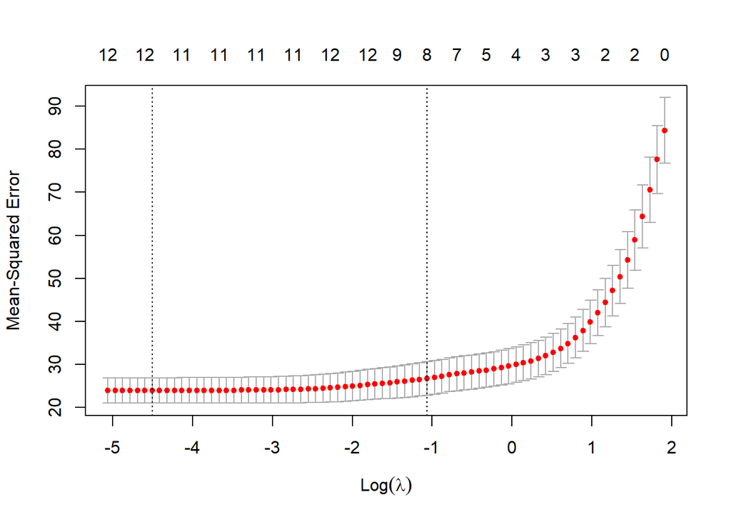

```r
#use 5-fold cross validation to pick lambda
cv_lasso_fit = cv.glmnet(x = as.matrix(Boston[, -c(which(colnames(Boston)=='medv'))]), y = Boston$medv, alpha = 1, nfolds = 5)
plot(cv_lasso_fit)
```

The best $\lambda$ (or *s*) is given by:

```r
cv_lasso_fit$lambda.min
```

```
## [1] 0.01104589
```

Given a selected *s* you can use *predict()* this way to get prediction:

```r
Boston.insample.prediction = predict(lasso_fit, as.matrix(Boston[, -c(which(colnames(Boston)=='medv'))]), s = cv_lasso_fit$lambda.min)
```

> **Exercise**: For a high dimensional dataset having n<p (n=200, p=500), is it possible to fit a linear regression on that directly? Fit a model with first five variables. How about LASSO variable selection?

[1]: Tibshirani, R. (1996). Regression shrinkage and selection via the lasso. Journal of the Royal Statistical Society. Series B (Methodological), 267-288. [2]: Zou, H., & Hastie, T. (2005). Regularization and variable selection via the elastic net. Journal of the Royal Statistical Society: Series B (Statistical Methodology), 67(2), 301-320.  
[3]: http://www.stanford.edu/~hastie/TALKS/enet_talk.pdf “Regularization and Variable Selection via the Elastic Net”

go to top

# 4 Simulation Exercise

Assume mean function $E(y|x)= 5 + 1.2*x_1 +3*x_2$

- Generate data with $x_1 \sim N(2,.4^2)$, $x_2 \sim N(-1, .1^2)$, sample size $n=200$, and error term $\varepsilon\sim N(0,\sigma^2)$, where $\sigma^2=1$.

```r
#sample code for hw2 p3
#monte carlo simulation
n <- 200 #sample size
m <- 100 #number of simulation iterations
#part i) simulate predictors X

#part ii)
for(j in 1:m){
  #simulate the error term m=100 times...
  #generate response vector y with error term per iteration
  lm.out <- ?? #fit linear regression
  betaMatrix[j,] <- lm.out$coefficients
  mysummary <- summary(lm.out)
  listMSE[j] <- mysummary$sigma^2 #get MSE per iteration
  }
#part iii) compute MSE bias etc
beta_mean <- apply(betaMatrix,2,mean)
beta_var <- apply(betaMatrix,2,var)
```

go to top

# 5 Cross Validation

Cross validation is an alternative approach to training/testing split. For k-fold cross validation, the dataset is divided into k parts. Each part serves as the test set in each iteration and the rest serve as training set. The out-of-sample performance measures from the k iterations are averaged.

Note

1. We use the **entire** dataset for cross validation
2. We need to use glm instead of lm to fit the model (if we want to use cv.glm fucntion in boot package)
3. The default measure of performance is the Mean Squared Error (MSE). If we want to use another measure we need to define a cost function.

## 5.1 5-fold Cross Validation

```r
library(boot)
model_2 <- glm(medv~indus + rm, data = Boston)
cv.glm(data = Boston, glmfit = model_2, K = 5)$delta[2]
```

```
## [1] 40.40284
```

## 5.2 LOOCV (Leave-one-out Cross Validation)

```r
cv.glm(data = Boston, glmfit = model_2, K = nrow(Boston))$delta[2]
```

```
## [1] 39.94028
```

## 5.3 5-fold Cross Validation Using MAE

Here we need to define a MAE cost function. The function takes 2 input vectors, pi = predicted values, r = actual values.

```r
model_2 <- glm(medv~indus + rm, data = Boston)

MAE_cost <- function(pi, r){
  return(mean(abs(pi-r)))
}

cv.glm(data = Boston, glmfit = model_2, cost = MAE_cost, K = 5)$delta[2]
```

```
## [1] 4.257306
```

Another package DAAG also does cross validation. It prints out the performance in each fold and gives you a plot at the end. But currently I cannot figure out how to get the cross-validation error programmatically.

```r
install.packages('DAAG')
```

```r
library(DAAG)
```

```r
model_2 <- lm(medv~indus + rm, data = Boston)
cv.lm(df=Boston, form.lm = model_2, m=3)
```

[output not shown]

go to top

# 6 Diagnostic Plots

The diagnostic plots are not as important when regression is used in predictive (supervised) data mining as when it is used in economics. However it is still good to know:

1. What the diagnostic plots should look like when no assumption is violated?
2. If there is something wrong, what assumptions are possibly violated?
3. What implications does it have on the analysis?
4. (How) can I fix it?

Roughly speaking, the table summarizes what you should look for in the following plots

| Plot Name | Good |
| --- | --- |
| Residual vs. Fitted | No pattern, scattered around 0 line |
| Normal Q-Q | Dots fall on dashed line |
| Residual vs. Leverage | No observation with large Cook’s distance |

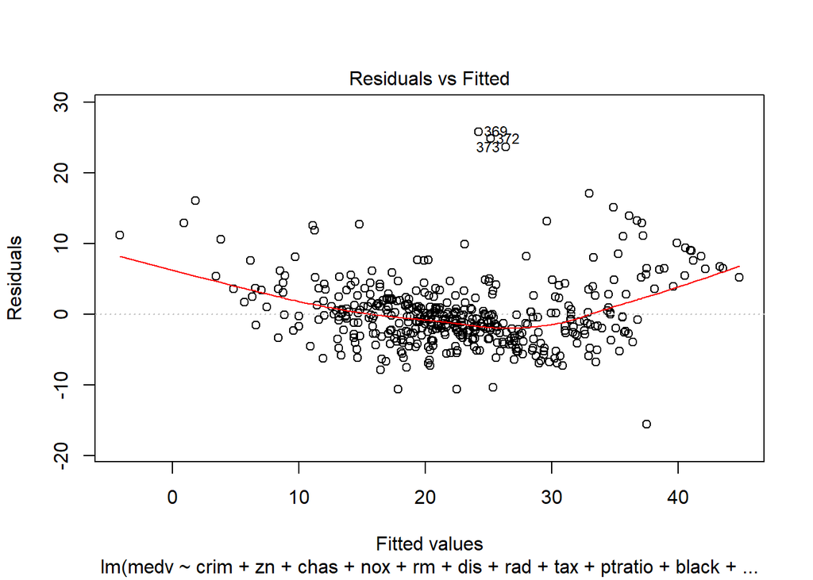

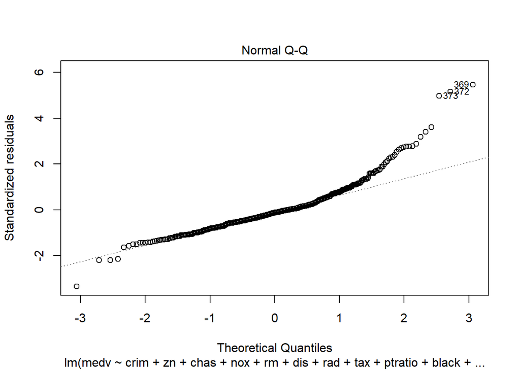

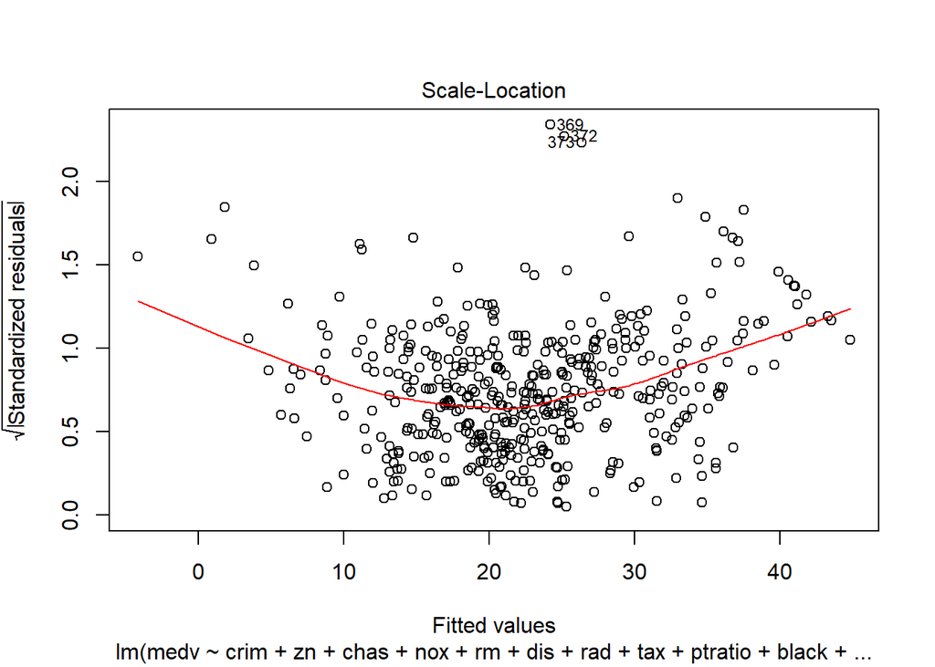

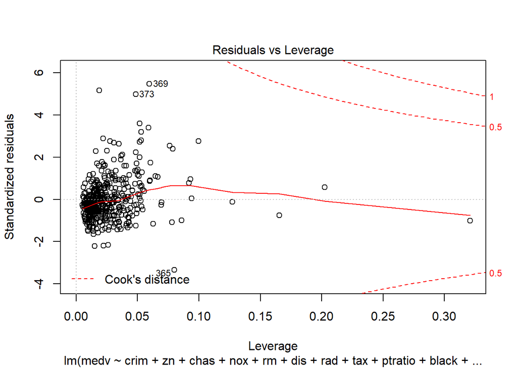

```r
plot(model_1)
```

go to top